# Titanic_Binary_Logistic

I Joly

09/10/2019

# Titanic Case Study - (source: F.E. Harrel, (2015), Regression Modeling Strategies, 2nd Ed., Springer, chap. 12)

This case study demonstrates the development of a binary logistic regression model to describe patterns of survival in passengers on the Titanic, based on passenger age, sex, ticket class, and the number of family members accompanying each passenger. Nonparametric regression is also used. Since many of the passengers had missing ages, multiple imputation is used so that the complete information on the other variables can be efficiently utilized. Titanic passenger data were gathered by many researchers. Primary references are the Encyclopedia Titanica at www.encyclopedia-titanica.org and Eaton and Haas.Titanic survival patterns have been analyzed previously but without incorporation of individual passenger ages. Thomas Cason while a University of Virginia student compiled and interpreted the data from the World Wide Web. One thousand three hundred nine of the passengers are represented in the dataset, which is available from this text’s Web site under the name titanic3. An early analysis of Titanic data may be found in Bron.

## Descriptive Statistics

We select the variables of interest

```r
require(rms)
# getHdata(titanic3) # get dataset from web site
# save(titanic3, file = "G:/IRA/888_ESE UPMF/2019_C2ES_M2_Econometrie3/Scripts and Dataframes/titanic3.RData")

load("G:/IRA/888_ESE UPMF/2019_C2ES_M2_Econometrie3/Scripts and Dataframes/titanic3.RData")

# List of names of variables to analyze
v <-  c('pclass', 'survived', 'age', 'sex', 'sibsp', 'parch')
t3 <-  titanic3[, v]
units(t3$age) <-  'years '
describe(t3)
```

```
## t3
##
##  6  Variables      1309  Observations
## --------------------------------------------------------------------------------
## pclass
##        n  missing distinct
##     1309        0        3
##
## Value        1st   2nd   3rd
## Frequency    323   277   709
## Proportion 0.247 0.212 0.542
## --------------------------------------------------------------------------------
## survived : Survived
##        n  missing distinct     Info      Sum     Mean      Gmd
##     1309        0        2    0.708      500    0.382   0.4725
##
## --------------------------------------------------------------------------------
## age : Age [years ]
##        n  missing distinct     Info     Mean      Gmd      .05      .10
##     1046      263       98    0.999    29.88    16.06        5       14
##      .25      .50      .75      .90      .95
##       21       28       39       50       57
##
## lowest :  0.1667  0.3333  0.4167  0.6667  0.7500
## highest: 70.5000 71.0000 74.0000 76.0000 80.0000
## --------------------------------------------------------------------------------
## sex
##        n  missing distinct
##     1309        0        2
##
## Value      female   male
## Frequency     466    843
## Proportion  0.356  0.644
## --------------------------------------------------------------------------------
## sibsp : Number of Siblings/Spouses Aboard
##        n  missing distinct     Info     Mean      Gmd
##     1309        0        7     0.67   0.4989    0.777
##
## lowest : 0 1 2 3 4, highest: 2 3 4 5 8
##
## Value          0     1     2     3     4     5     8
## Frequency    891   319    42    20    22     6     9
## Proportion 0.681 0.244 0.032 0.015 0.017 0.005 0.007
## --------------------------------------------------------------------------------
## parch : Number of Parents/Children Aboard
##        n  missing distinct     Info     Mean      Gmd
##     1309        0        8    0.549    0.385   0.6375
##
## lowest : 0 1 2 3 4, highest: 3 4 5 6 9
##
## Value          0     1     2     3     4     5     6     9
## Frequency   1002   170   113     8     6     6     2     2
## Proportion 0.765 0.130 0.086 0.006 0.005 0.005 0.002 0.002
## --------------------------------------------------------------------------------
```

We save the data distribution characteristics (for calculous of predictors, figures, etc) We truncate the distribution of `sibsp` and `parch` at 3 (more than 3 spouses or more than 3 children) Missing values are noticeable for `age`.

To study show four-way empirical relationships with the fraction of surviving passengers by creating four cells for `sibsp × parch` combinations and by creating two age groups. We suppress proportions based on less than 25 passengers.

Last 2 variables have non-monotonic effects.

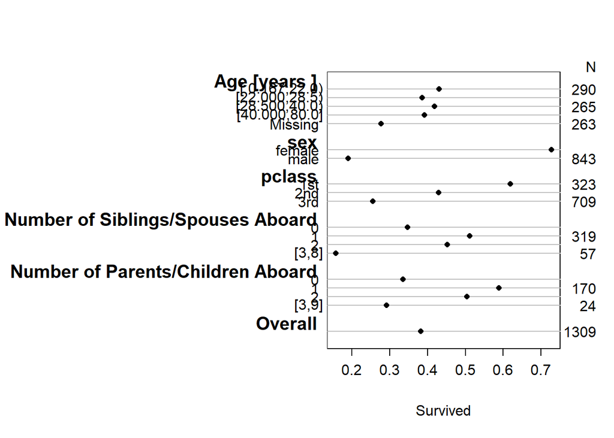

```r
dd <-  datadist(t3)    # describe distributions of variables to rms
options(datadist = 'dd' )
s <-  summary(survived ∼ age + sex + pclass + cut2(sibsp ,0:3) + cut2(parch ,0:3), data =t3)
plot(s, main = ' ' , subtitles =FALSE ) # Figure 12.1
```

## Non parametric exploration

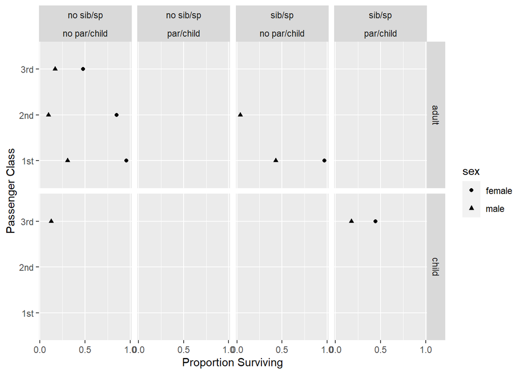

```r
tn <-  transform (t3 ,
agec = ifelse(age < 21, ' child ' , ' adult ' ),
sibsp = ifelse(sibsp == 0, ' no sib/sp ' , ' sib/sp ' ),
parch = ifelse(parch == 0, ' no par/child ' , ' par/child ' ))
g <-  function(y) if(length (y) < 25) NA else mean(y)
s <-  with(tn , summarize (survived , llist(agec , sex , pclass , sibsp , parch ), g))
# llist , summarize in Hmisc package
# Figure 12.2:
ggplot(subset(s, agec != ' NA ' ),
aes(x=survived , y=pclass , shape =sex)) +
geom_point() + facet_grid(agec ∼ sibsp * parch ) +
xlab( ' Proportion Surviving ' ) + ylab( ' Passenger Class ') +
scale_x_continuous(breaks =c(0, .5 , 1))
```

Effects of `sibsp` and `parch` seem small on absolute risk.

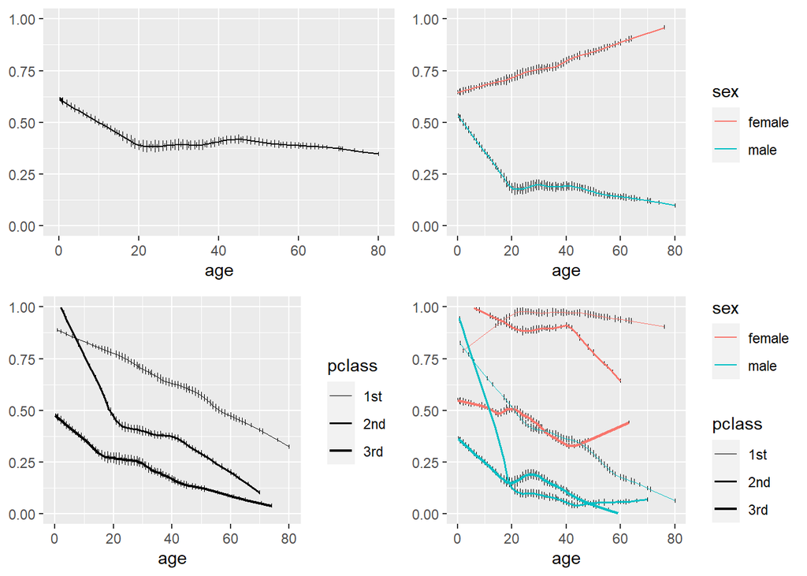

```r
# Figure 12.3
b <-  scale_size_discrete(range =c(.1 , .85))
yl <-  ylab(NULL)
p1 <-  ggplot(t3 , aes(x=age , y=survived )) +
  histSpikeg(survived ∼ age , lowess =TRUE , data =t3) +
  ylim (0,1) + yl
p2 <-  ggplot(t3 , aes(x=age , y=survived , color =sex)) +
  histSpikeg (survived ∼ age + sex , lowess =TRUE ,data =t3) + ylim (0,1) +
  yl
p3 <-  ggplot(t3 , aes(x=age , y=survived , size =pclass )) +
  histSpikeg (survived ∼ age + pclass , lowess =TRUE, data =t3) +
  b + ylim (0,1) + yl
p4 <-  ggplot(t3 , aes(x=age , y=survived , color =sex, size =pclass )) +
  histSpikeg (survived ∼ age + sex + pclass, lowess =TRUE , data =t3) +
  b + ylim (0,1) + yl
gridExtra::grid.arrange(p1 , p2 , p3 , p4 , ncol =2) # combine 4
```

Nonparametric regression (loess) estimates of the relationship between age and the probability of surviving the Titanic, with tick marks depicting the age distribution. The top left panel shows unstratified estimates of the probability of survival. Other panels show nonparametric estimates by various stratifications

Figure shows much of the story of passenger survival patterns.“Women and children first” seems to be true except for women in third class. It is interesting that there is no real cutoff for who is considered a child. For men, the younger the greater chance of surviving. The interpretation of the effects of the “number of relatives”-type variables will be more difficult, as their definitions are a function of age. Figure 12.4 shows these relationships.

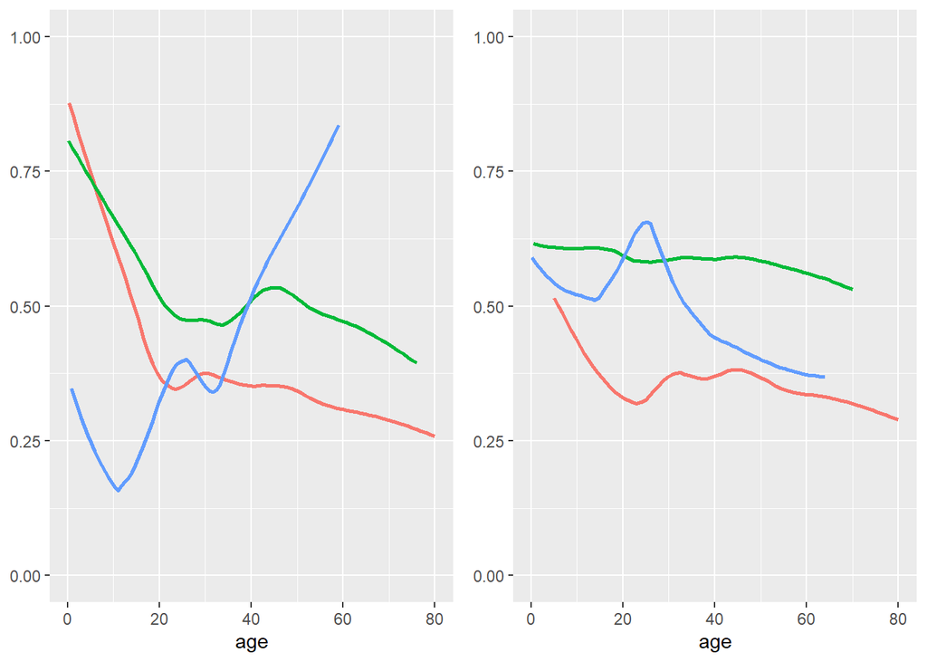

```r
top <-  theme(legend.position = ' top ' )
p1 <-  ggplot(t3 , aes(x=age , y=survived , color =cut2(sibsp , 0:2))) +
  stat_plsmo() + b + ylim(0,1) + yl + top +
  scale_color_discrete(name= ' siblings /spouses ' )

p2 <-  ggplot(t3 , aes(x=age , y=survived , color =cut2(parch , 0:2))) +
  stat_plsmo() + b + ylim(0,1) + yl + top +
  scale_color_discrete(name= ' parents/children ' )
gridExtra::grid.arrange(p1 , p2 , ncol =2)
```

The standard analysis is performed eliminating observations having any missing data. A first logistic model is developped allowing for a flexible nonlinear `age` effect that can differ in shape for all six `sex × class` strata. The `sibsp` and `parch` variables do not have sufficiently dispersed distributions to allow for us to model them nonlinearly.

Also, there are too few passengers with nonzero values of these two variables in `sex × pclass × age` strata to allow us to model complex interactions involving them. The meaning of these variables does depend on the passenger’s age, so we consider only age interactions involving `sibsp` and `parch`.

```r
tab1 <-  datadist(t3)
# describe distributions of variables to rms
options(datadist = 'tab1' )
model1 <-  lrm(survived ∼ sex*pclass *rcs(age ,5) + rcs(age ,5)*(sibsp + parch ), data =t3) # Table 12.1
kable(anova(model1))
```

|  | Chi-Square | d.f. | P |
| --- | --- | --- | --- |
| sex (Factor+Higher Order Factors) | 187.145302 | 15 | 0.0000000 |
| All Interactions | 59.736939 | 14 | 0.0000001 |
| pclass (Factor+Higher Order Factors) | 100.103312 | 20 | 0.0000000 |
| All Interactions | 46.505901 | 18 | 0.0002502 |
| age (Factor+Higher Order Factors) | 56.201773 | 32 | 0.0051601 |
| All Interactions | 34.574035 | 28 | 0.1826085 |
| Nonlinear (Factor+Higher Order Factors) | 28.661607 | 24 | 0.2331267 |
| sibsp (Factor+Higher Order Factors) | 19.668534 | 5 | 0.0014419 |
| All Interactions | 12.125646 | 4 | 0.0164410 |
| parch (Factor+Higher Order Factors) | 3.511450 | 5 | 0.6216558 |
| All Interactions | 3.511449 | 4 | 0.4761396 |
| sex * pclass (Factor+Higher Order Factors) | 42.429490 | 10 | 0.0000063 |
| sex * age (Factor+Higher Order Factors) | 15.891662 | 12 | 0.1962487 |
| Nonlinear (Factor+Higher Order Factors) | 14.467764 | 9 | 0.1066318 |
| Nonlinear Interaction : f(A,B) vs. AB | 4.165654 | 3 | 0.2441232 |
| pclass * age (Factor+Higher Order Factors) | 13.465106 | 16 | 0.6384951 |
| Nonlinear (Factor+Higher Order Factors) | 12.919791 | 12 | 0.3748975 |
| Nonlinear Interaction : f(A,B) vs. AB | 6.876465 | 6 | 0.3324230 |
| age * sibsp (Factor+Higher Order Factors) | 12.125646 | 4 | 0.0164410 |
| Nonlinear | 1.760926 | 3 | 0.6234746 |
| Nonlinear Interaction : f(A,B) vs. AB | 1.760926 | 3 | 0.6234746 |
| age * parch (Factor+Higher Order Factors) | 3.511449 | 4 | 0.4761396 |
| Nonlinear | 1.800962 | 3 | 0.6147255 |
| Nonlinear Interaction : f(A,B) vs. AB | 1.800962 | 3 | 0.6147255 |
| sex * pclass * age (Factor+Higher Order Factors) | 8.344319 | 8 | 0.4005789 |
| Nonlinear | 7.735660 | 6 | 0.2581162 |
| TOTAL NONLINEAR | 28.661607 | 24 | 0.2331267 |
| TOTAL INTERACTION | 75.608313 | 30 | 0.0000083 |
| TOTAL NONLINEAR + INTERACTION | 79.494512 | 33 | 0.0000104 |
| TOTAL | 241.934243 | 39 | 0.0000000 |

A second model introduces second-order interactions

```r
full3 <- lrm(survived ∼ (sex + pclass + rcs(age ,5))^2 + rcs(age ,5)*sibsp , data=t3)
full3
```

```
## Frequencies of Missing Values Due to Each Variable
## survived      sex   pclass      age    sibsp
##        0        0        0      263        0
##
## Logistic Regression Model
##
##  lrm(formula = survived ~ (sex + pclass + rcs(age, 5))^2 + rcs(age,
##      5) * sibsp, data = t3)
##
##
##                        Model Likelihood     Discrimination    Rank Discrim.
##                           Ratio Test           Indexes           Indexes
##  Obs          1046    LR chi2     553.87    R2       0.555    C       0.878
##   0            619    d.f.            26    g        2.427    Dxy     0.756
##   1            427    Pr(> chi2) <0.0001    gr      11.325    gamma   0.758
##  max |deriv| 6e-06                          gp       0.365    tau-a   0.366
##                                             Brier    0.130
##
##                        Coef    S.E.   Wald Z Pr(>|Z|)
##  Intercept              3.3075 1.8427  1.79  0.0727
##  sex=male              -1.1478 1.0878 -1.06  0.2914
##  pclass=2nd             6.7309 3.9617  1.70  0.0893
##  pclass=3rd            -1.6437 1.8299 -0.90  0.3691
##  age                    0.0886 0.1346  0.66  0.5102
##  age'                  -0.7410 0.6513 -1.14  0.2552
##  age''                  4.9264 4.0047  1.23  0.2186
##  age'''                -6.6129 5.4100 -1.22  0.2216
##  sibsp                 -1.0446 0.3441 -3.04  0.0024
##  sex=male * pclass=2nd -0.7682 0.7083 -1.08  0.2781
##  sex=male * pclass=3rd  2.1520 0.6214  3.46  0.0005
##  sex=male * age        -0.2191 0.0722 -3.04  0.0024
##  sex=male * age'        1.0842 0.3886  2.79  0.0053
##  sex=male * age''      -6.5578 2.6511 -2.47  0.0134
##  sex=male * age'''      8.3716 3.8532  2.17  0.0298
##  pclass=2nd * age      -0.5446 0.2653 -2.05  0.0401
##  pclass=3rd * age      -0.1634 0.1308 -1.25  0.2118
##  pclass=2nd * age'      1.9156 1.0189  1.88  0.0601
##  pclass=3rd * age'      0.8205 0.6091  1.35  0.1780
##  pclass=2nd * age''    -8.9545 5.5027 -1.63  0.1037
##  pclass=3rd * age''    -5.4276 3.6475 -1.49  0.1367
##  pclass=2nd * age'''    9.3926 6.9559  1.35  0.1769
##  pclass=3rd * age'''    7.5403 4.8519  1.55  0.1202
##  age * sibsp            0.0357 0.0340  1.05  0.2933
##  age' * sibsp          -0.0467 0.2213 -0.21  0.8330
##  age'' * sibsp          0.5574 1.6680  0.33  0.7382
##  age''' * sibsp        -1.1937 2.5711 -0.46  0.6425
##
```

ROC area (`c`= 0.878) indicates a powerfull model.

```r
anova(full3)
```

```
##                 Wald Statistics          Response: survived
##
##  Factor                                      Chi-Square d.f. P
##  sex  (Factor+Higher Order Factors)          199.42      7   <.0001
##   All Interactions                            56.14      6   <.0001
##  pclass  (Factor+Higher Order Factors)       108.73     12   <.0001
##   All Interactions                            42.83     10   <.0001
##  age  (Factor+Higher Order Factors)           47.04     20   0.0006
##   All Interactions                            24.51     16   0.0789
##   Nonlinear (Factor+Higher Order Factors)     22.72     15   0.0902
##  sibsp  (Factor+Higher Order Factors)         19.95      5   0.0013
##   All Interactions                            10.99      4   0.0267
##  sex * pclass  (Factor+Higher Order Factors)  35.40      2   <.0001
##  sex * age  (Factor+Higher Order Factors)     10.08      4   0.0391
##   Nonlinear                                    8.17      3   0.0426
##   Nonlinear Interaction : f(A,B) vs. AB        8.17      3   0.0426
##  pclass * age  (Factor+Higher Order Factors)   6.86      8   0.5516
##   Nonlinear                                    6.11      6   0.4113
##   Nonlinear Interaction : f(A,B) vs. AB        6.11      6   0.4113
##  age * sibsp  (Factor+Higher Order Factors)   10.99      4   0.0267
##   Nonlinear                                    1.81      3   0.6134
##   Nonlinear Interaction : f(A,B) vs. AB        1.81      3   0.6134
##  TOTAL NONLINEAR                              22.72     15   0.0902
##  TOTAL INTERACTION                            67.58     18   <.0001
##  TOTAL NONLINEAR + INTERACTION                70.68     21   <.0001
##  TOTAL                                       253.18     26   <.0001
```

### Exploration of estimated effects

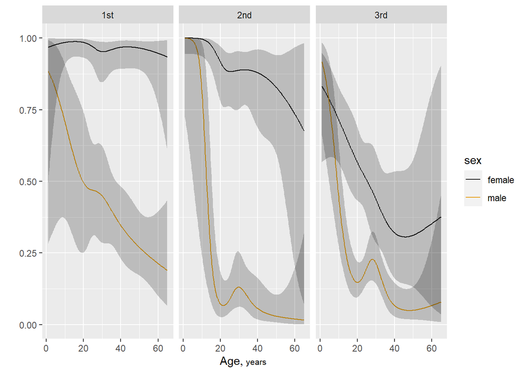

```r
p <-  Predict(full3, age , sex , pclass , sibsp =0, fun=plogis )
ggplot (p)
```

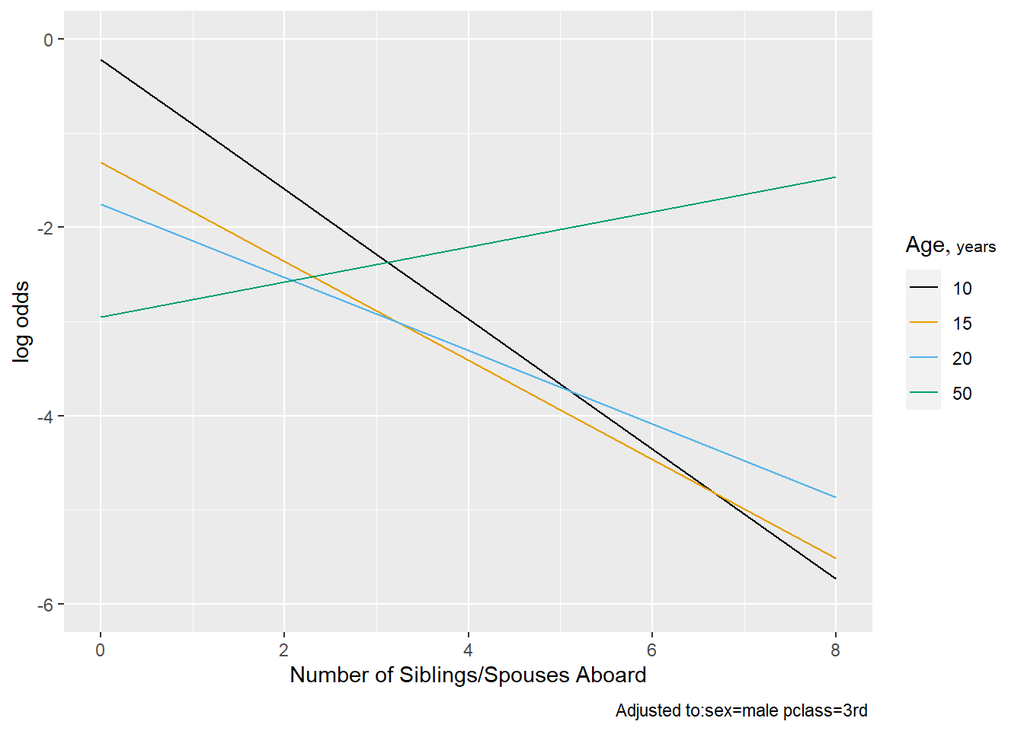

```r
ggplot (Predict(full3, sibsp , age=c(10 ,15 ,20,50), conf.int=FALSE ))
```

> Note that children having many siblings apparently had lower survival. Married adults had slightly higher survival than unmarried ones

## Bootstrap and fit quality

There will never be another Titanic, so we do not need to validate the model for prospective use. But we use the bootstrap to validate the model anyway, in an effort to detect whether it is overfitting the data.

```r
full3  <-  update(full3, x=TRUE , y=TRUE)
# x=TRUE , y=TRUE adds raw data to fit object so can bootstrap
set.seed (131) # so can replicate re-samples
validate(full3, B=200)
```

```
##           index.orig training    test optimism index.corrected   n
## Dxy           0.7560   0.7721  0.7407   0.0314          0.7246 200
## R2            0.5545   0.5778  0.5262   0.0516          0.5029 200
## Intercept     0.0000   0.0000 -0.0788   0.0788         -0.0788 200
## Slope         1.0000   1.0000  0.8649   0.1351          0.8649 200
## Emax          0.0000   0.0000  0.0460   0.0460          0.0460 200
## D             0.5286   0.5585  0.4936   0.0649          0.4637 200
## U            -0.0019  -0.0019  0.0061  -0.0080          0.0061 200
## Q             0.5305   0.5604  0.4876   0.0729          0.4576 200
## B             0.1303   0.1256  0.1342  -0.0086          0.1389 200
## g             2.4270   2.7789  2.3963   0.3826          2.0444 200
## gp            0.3655   0.3725  0.3536   0.0189          0.3466 200
```

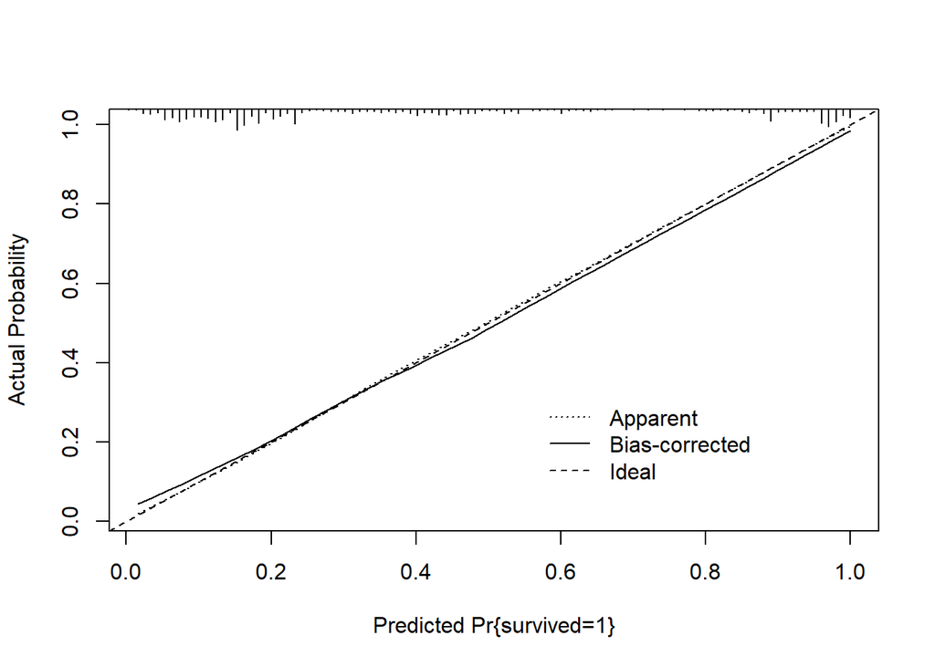

```
##
## n=1046   Mean absolute error=0.011   Mean squared error=0.00016
## 0.9 Quantile of absolute error=0.018
```

```r
cal <-  calibrate(full3, B=200) # Figure 12.7
plot(cal , subtitles =FALSE )
```

> The output of validate indicates minor overfitting. Overfitting would have been worse had the risk factors not been so strong. The closeness of the calibration curve to the 45° line in the figure demonstrates excellent validation on an absolute probability scale. But the extent of missing data casts some doubt on the validity of this model, and on the efficiency of its parameter estimates

## Summarizing the Fitted Model

Computing odds ratios and by showing various predicted values. For age, the odds ratio for an increase from 1 year old to 30 years old is computed, instead of the default odds ratio based on outer quartiles of age. The estimated odds ratios are very dependent on the levels of interacting factors, so Figure depicts only one of many patterns.

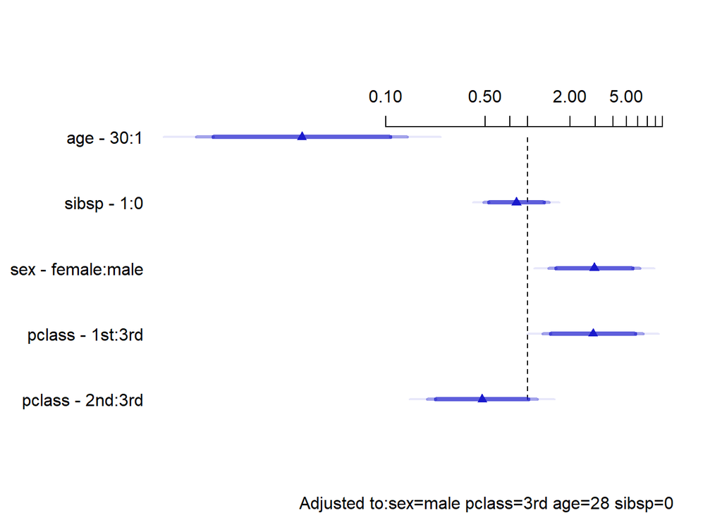

Odds ratios for some predictor settings

```r
# Get predicted values for certain types of passengers
s  <-  summary(full3 , age=c(1,30), sibsp =0:1)
# override default ranges for 3 variables
plot(s, log=TRUE , main='')
```

Now compute estimated probabilities of survival for a variety of settings of the predictors.

```r
phat  <-predict(full3,
combos <-
expand.grid(age=c(2,21,50) , sex=levels(t3$sex),
pclass =levels(t3$pclass ),
sibsp =0), type = 'fitted' )
# Can also use Predict(f.mi , age=c(2 ,21 ,50) , sex , pclass ,
# sibsp=0, fun=plogis)$yhat
options(digits =1)
data.frame(combos , phat)
```

```
##    age    sex pclass sibsp phat
## 1    2 female    1st     0 0.97
## 2   21 female    1st     0 0.98
## 3   50 female    1st     0 0.96
## 4    2   male    1st     0 0.87
## 5   21   male    1st     0 0.48
## 6   50   male    1st     0 0.27
## 7    2 female    2nd     0 1.00
## 8   21 female    2nd     0 0.90
## 9   50 female    2nd     0 0.83
## 10   2   male    2nd     0 1.00
## 11  21   male    2nd     0 0.07
## 12  50   male    2nd     0 0.03
## 13   2 female    3rd     0 0.82
## 14  21 female    3rd     0 0.55
## 15  50 female    3rd     0 0.31
## 16   2   male    3rd     0 0.89
## 17  21   male    3rd     0 0.15
## 18  50   male    3rd     0 0.05
```

We can also get predicted values by creating an R function that will evaluate the model on demand.

```r
pred.logit  <-  Function(full3)
pred.logit
```

```
## function (sex = "male", pclass = "3rd", age = 28, sibsp = 0)
## {
##     3.3074612 - 1.147806 * (sex == "male") + 6.7308688 * (pclass ==
##         "2nd") - 1.643696 * (pclass == "3rd") + 0.088598205 *
##         age - 0.00027403402 * pmax(age - 5, 0)^3 + 0.0018218967 *
##         pmax(age - 21, 0)^3 - 0.0024456171 * pmax(age - 28, 0)^3 +
##         0.00097921926 * pmax(age - 37, 0)^3 - 8.1464797e-05 *
##         pmax(age - 57, 0)^3 - 1.0446073 * sibsp + (sex == "male") *
##         (-0.76821735 * (pclass == "2nd") + 2.1519988 * (pclass ==
##             "3rd")) + (sex == "male") * (-0.21910626 * age +
##         0.00040097023 * pmax(age - 5, 0)^3 - 0.0024252223 * pmax(age -
##         21, 0)^3 + 0.0030960067 * pmax(age - 28, 0)^3 - 0.0011663321 *
##         pmax(age - 37, 0)^3 + 9.4577515e-05 * pmax(age - 57,
##         0)^3) + (pclass == "2nd") * (-0.54458849 * age + 0.00070842582 *
##         pmax(age - 5, 0)^3 - 0.0033115613 * pmax(age - 21, 0)^3 +
##         0.0034736026 * pmax(age - 28, 0)^3 - 0.00091782054 *
##         pmax(age - 37, 0)^3 + 4.7353438e-05 * pmax(age - 57,
##         0)^3) + (pclass == "3rd") * (-0.16335153 * age + 0.00030342121 *
##         pmax(age - 5, 0)^3 - 0.0020072459 * pmax(age - 21, 0)^3 +
##         0.0027885898 * pmax(age - 28, 0)^3 - 0.0012193077 * pmax(age -
##         37, 0)^3 + 0.00013454263 * pmax(age - 57, 0)^3) + sibsp *
##         (0.035708443 * age - 1.7252348e-05 * pmax(age - 5, 0)^3 +
##             0.00020614832 * pmax(age - 21, 0)^3 - 0.00044145778 *
##             pmax(age - 28, 0)^3 + 0.00031390291 * pmax(age -
##             37, 0)^3 - 6.1341103e-05 * pmax(age - 57, 0)^3)
## }
## <environment: 0x0000000028469620>
```

```r
# pred.logit  <- function(sex = "male",pclass = "3rd",age = 28,sibsp = 0) {3.3074612-1.147806*(sex=="male")+6.7308688*(pclass=="2nd")-1.643696*(pclass=="3rd")+0.088598205* age-0.00027403402*pmax(age-5,0)^3+0.0018218967*pmax(age-21,0)^3-0.0024456171*pmax(age-28,0)^3+0.00097921926*pmax(age-37,0)^3-8.1464797e-05*pmax(age-57,0)^3-1.0446073*sibsp+(sex=="male")*(-0.76821735*(pclass=="2nd")+2.1519988*(pclass=="3rd"))+(sex=="male")*(-0.21910626* age+0.00040097023*pmax(age-5,0)^3-0.0024252223*pmax(age-21,0)^3+0.0030960067*pmax(age-28,0)^3-0.0011663321*pmax(age-37,0)^3+9.4577515e-05*pmax(age-57,0)^3)+(pclass=="2nd")*(-0.54458849* age+0.00070842582*pmax(age-5,0)^3-0.0033115613*pmax(age-21,0)^3+0.0034736026*pmax(age-28,0)^3-0.00091782054*pmax(age-37,0)^3+4.7353438e-05*pmax(age-57,0)^3)+(pclass=="3rd")*(-0.16335153* age+0.00030342121*pmax(age-5,0)^3-0.0020072459*pmax(age-21,0)^3+0.0027885898*pmax(age-28,0)^3-0.0012193077*pmax(age-37,0)^3+0.00013454263*pmax(age-57,0)^3)+sibsp*(0.035708443* age-1.7252348e-05*pmax(age-5,0)^3+0.00020614832*pmax(age-21,0)^3-0.00044145778*pmax(age-28,0)^3+0.00031390291*pmax(age-37,0)^3-6.1341103e-05*pmax(age-57,0)^3) }



plogis(pred.logit(age=c(2,21,50) , sex= 'male' , pclass = '3rd' ))
```

```
## [1] 0.89 0.15 0.05
```